# Leíró statisztikai eszközök R-ben

## 5. A szórás

A Moodle-n található Befektetes.xlsx fájl egy olyan adattábla, ami a két befektetési alap 1235 napon keresztül mért napi aráfolyamváltozásait tárolja *euróban* 2012 és 2017 között. A két befektetési alap az alábbi:

- **Climate Change** részvény befektetési alap
- **BondMaxx** kötvény befektetési alap

Töltsük be az Excel fájlt egy R `data frame`-be! Az *xlsx* kiterjesztésű Excel fájlokat a `readxl` csomag `read_excel` függvényével tudjuk R `data frame`-ben elraktározni.

Telepítsük a csomagot:

```r
install.packages("readxl")
library(readxl) # Szokásos módon ne törődjünk az esetleges Warningokkal! :)
```

Majd használjuk a csomag `read_excel` függvényét. Amennyiben 1 db munkalap van és a beolasandó adattáblánk az *A1* cellában van, mindenféle extra paraméter nélkül, problémamentesen beolvassa gépállat az adatokat R `data frame`-be:

```r
befektetes <- read_excel("Befektetes.xlsx")

str(befektetes)
```

```
## tibble [1,235 × 3] (S3: tbl_df/tbl/data.frame)
##  $ Nap                   : POSIXct[1:1235], format: "2012-11-30" "2012-12-03" ...
##  $ ClimateChange_Reszveny: num [1:1235] 0.0965 0.3114 -0.1869 0.4785 0.5165 ...
##  $ BondMaxx_Kotveny      : num [1:1235] 0.068 0.0689 0.0518 0.0694 0.1908 ...
```

Minden szupinak néz ki! Mindkét befektetési alapunkra van 1235 db megfigyelés. Az `str` függvényünk eredménye alapján pedig láthatjuk, hogy pl. a 3. megfigyelés esetén, 2012.12.04-én a részvényalapunk értéke 0.18 euróval *csökkent*, míg a kötvényalapunk értéke 0.05 euróval *nőtt*.

Ha el kellene döntenünk, hogy 100 elkölthető eurót melyik befekktetési lehetőségbe fektessük be, akkor csábító az a megoldás, hogy abba a befektetésbe fektessünk be, aminek az átlagos napi árfolyamváltozása magasabb.  
Számoljuk akkor ki ezeket az átlagokat:

```r
mean(befektetes$ClimateChange_Reszveny)
```

```
## [1] 0.04208988
```

```r
mean(befektetes$BondMaxx_Kotveny)
```

```
## [1] 0.01746529
```

Egy átlagos napon a részvény befeketetés +0.04 eurót hoz a konyhára, míg a kötvény befektetés +0.017 eurót termel egy átlagos nap. Ezen a ponton csábító, hogy azt mondjuk, hogy az átlagos árfolyamnyereség a részvény befektetésnél nagyobb, akkor oda szórjuk el 100 eltapsolható eurónkat.

Azért a biztonság kedvéért azért nézzünk rá erre a `data frame`-re is egy `summary` függvénnyel és minimum lessük meg hogyan alakulnak a kvartilisek:

```r
summary(befektetes)
```

```
##       Nap                         ClimateChange_Reszveny BondMaxx_Kotveny
##  Min.   :2012-11-30 00:00:00.00   Min.   :-8.91586       Min.   :-0.520116
##  1st Qu.:2014-03-10 12:00:00.00   1st Qu.:-0.41252       1st Qu.:-0.005535
##  Median :2015-06-09 00:00:00.00   Median : 0.07170       Median : 0.016513
##  Mean   :2015-06-06 00:29:08.99   Mean   : 0.04209       Mean   : 0.017465
##  3rd Qu.:2016-09-03 12:00:00.00   3rd Qu.: 0.50639       3rd Qu.: 0.041623
##  Max.   :2017-11-27 00:00:00.00   Max.   : 3.89820       Max.   : 0.661567
```

Azért a kvartilisek és a minimum-maximum viszonyából láthatjuk, hogy azért vannak kilógó értékek a változókban *mindkét* irányban! Pl. a részvénynél a napok 75%-a olyan, hogy 0.5 euró alatti az árfolyamváltozás, de előfordult 3.9 eurós árfolyamnövekedés is. A kötvénynél pedig a veszteségek legnagyobb 25%-a (tehát az árfolyamváltozások legkisebb 25%-a) 0.0055 eurónál nagyobb mínusz csak, de van -0.52 eurós veszteségünk is!

Szóval, mindkét változóban vannak kilógó értékek, de mivel *mindkét* irányba előfordulnak ezek, így ezt az átlag-medián eltérésből nem detektáljuk, de a két szélső kvartilis és a minimum-maximum viszonyából azért láthatjuk, hogy egy konkrét érték az átlagtól eléggé erősen is eltérhet.  
Ebből a tapasztalásból felmerül az igény egy **mutatóra, ami megméri, hogy várhatóan mennyi az eltérés a változó egy eleme és a változó átlaga között**. Ez a mutató lesz a **szórás**.

A fent megfogalmazott jelentéstartalom miatt logikus lenne úgy számolni a szórást, hogy megnézzük a változó minden $Y_i$ elemének az $\bar{Y}$ átlagtól vett eltérését és ezeket az $Y_i-\bar{Y}$ eltéréseket átlagoljuk.

Szóval első nekifutásnak a szórást úgy számolnánk, hogy $\frac{\sum_{i=1}^N{Y_i-\bar{Y}}}{N}$ ha az elemszám továbbra is $N$-nel jelölődik. Próbáljuk is ki ezt a képletet a részvény befektetésen:

```r
N <- nrow(befektetes) # a dataframe sorainak száma tehát az elemszám :)
atlag_reszveny <- mean(befektetes$ClimateChange_Reszveny)
sum(befektetes$ClimateChange_Reszveny - atlag_reszveny) / N
```

```
## [1] -1.154329e-17
```

Kijött, hogy a szórásunk lényegében 0, egész konkrétan normálalakban $-1.15 \times 10^{-17}$. Kicsit fura, nem? :)

Nos, a háttérben az van, hogy az átlagtól el lehet térni felfelé és lefelé is. Ezek az eltérő előjelű eltérések pedig szépen kioltják egymást, és az összeg a számlálóban lényegében 0 lesz.

Ezt ki lehet küszöbölni kétféleképpen is:

- abszolút értékkel
- négyzetre emeléssel

Mi a második utat választjuk, a négyzetre emelést. Tehát először kiszámoljuk a **szórásnégyzetet, más szóval a varianciát**: $\sigma^2 = \frac{\sum_{i=1}^N{(Y_i-\bar{Y})^2}}{N}$

És ennek a gyöke lesz a szórás: $\sigma = \sqrt{\sigma^2} = \sqrt{\frac{\sum_{i=1}^N{(Y_i-\bar{Y})^2}}{N}}$

Kiszámolva manuálisan a részvény és kötvény befektetésekre is:

```r
N <- nrow(befektetes) # a dataframe sorainak száma tehát az elemszám :)

# Részvény szórás
atlag_reszveny <- mean(befektetes$ClimateChange_Reszveny)
sqrt(sum((befektetes$ClimateChange_Reszveny - atlag_reszveny)^2) / N)
```

```
## [1] 0.8389885
```

```r
# Kötvény szórás
atlag_kotveny <- mean(befektetes$BondMaxx_Kotveny)
sqrt(sum((befektetes$BondMaxx_Kotveny - atlag_kotveny)^2) / N)
```

```
## [1] 0.06133168
```

A kötvény befektetés esetén a szórást úgy kell érteni, hogy egy konkrét kereskedési napon az árfolyamváltozás várhatóan $\pm 0.06$ euróval tér el az átlagos árfolyamváltozástól. Míg részvény befektetés esetén azt láthatjuk, hogy egy konkrét kereskedési napon az árfolyamváltozás várhatóan $\pm 0.839$ euróval tér el az átlagos napi árfolyamváltozástól.  
Ez alapján pedig kijelenthetjük, hogy az átlagos árfolyamváltozás körül jobban szóródnak a konkrét napi árfolyamváltozások a *részvény* befektetés esetén, mint a *kötvény* befektetés esetén. Magyarul, a **részvény befektetés kockázatosabb**.

Sajnos erre az “alap” szórás képletre **nincs beépített függvény az R-ben**. Az R beépített szórás függvénye, az `sd` a szórást $\sigma = \sqrt{\frac{\sum_{i=1}^N{(Y_i-\bar{Y})^2}}{N-1}}$ képlettel számolja. Ezt le is tudjuk ellenőrizni:

```r
N <- nrow(befektetes) # a dataframe sorainak száma tehát az elemszám :)

# Részvény szórás R függvény verzió manuálisan
atlag_reszveny <- mean(befektetes$ClimateChange_Reszveny)
sqrt(sum((befektetes$ClimateChange_Reszveny - atlag_reszveny)^2) / (N-1))
```

```
## [1] 0.8393284
```

```r
# Részvény szórás R függvénnyel
sd(befektetes$ClimateChange_Reszveny)
```

```
## [1] 0.8393284
```

Jé, tényleg azonos a két számolási mód! Azt, hogy az R alapból miért így számol szórást, hogy $N-1$-gyel oszt, a következő alkalmon fogjuk megnézni.

Oké, tehát a részvény befektetés kockázatosabb, de egy átlagos napon mégis ő hozza a több eurót a konyhára. Akkor most hogy döntsek? Hát az ilyen dilemmák feloldására van a **relatív szórás** nevű mutatónk, ami a **szórás és az átlag hányadosa**, azaz $\frac{\sigma}{\bar{Y}}$. Magyarul megnézi, hogy az átlagos nyereséghez képest mekkora a kockázat, azaz a *szórás hányszorosa az átlagnak*.

Az értéke a két befektetésre a következő módon számolható:

```r
N <- nrow(befektetes) # a dataframe sorainak száma tehát az elemszám :)

# Részvény relatív szórás
atlag_reszveny <- mean(befektetes$ClimateChange_Reszveny)
szoras_reszveny <- sqrt(sum((befektetes$ClimateChange_Reszveny - atlag_reszveny)^2) / N)
szoras_reszveny/atlag_reszveny
```

```
## [1] 19.93326
```

```r
# Kötvény relatív szórás
atlag_kotveny <- mean(befektetes$BondMaxx_Kotveny)
szoras_kotveny <- sqrt(sum((befektetes$BondMaxx_Kotveny - atlag_kotveny)^2) / N)
szoras_kotveny/atlag_kotveny
```

```
## [1] 3.511631
```

Az átlagos nyereséghez képest a részvény befektetés esetén $19.9$-szeres kockázatot futunk, míg a kötvény esetén csak $3.5$-szöröst. Szóval, így az átlag és a szórás információit egy számba tekintve a kötvény befektetés tűnik a tutinak: mert az átlagos nyereséghez képest lényegesen kevesebbet kockáztatunk, mint a részvény befektetés esetében.

### 5.1. Az átlag optimum tulajdonsága (kiegészító anyag)

Az érdeklődőknek elregélem, hogy miért négyeztre emeléssel és nem abszolút értékkel kezeljük a szórásban az átlaghoz képesti eltérő előjelű eltéréseket. Ennek a négyzetre emelés preferálásnak az oka, hogy fontos követelmény a szórással szemben, hogy **deriválható** legyen. Erre azért van szükség, mert így meg tudjuk találni, hogy **mi az az $A$-val jelölt statisztikai mutató, amivel a változó minden értékét helyettesítve minimális szórást kapunk**. Az abszolút érték függvény pedig nem deriválható, ezért vetettük el.

De akkor lássuk mire is jó az, hogy a szórást tudjuk deriválni. Ugyebár a deriválás segítségével meg tudom találni egy $f(x)$ függvény minimumát/maximumát úgy, hogy a függvény deriváltját egyenlővé teszem 0-val és kifejezem az egyenletből, hogy ez milyen $x$ értékre teljesül.  
Pl. Onnan tudom, hogy a $f(x)=x^2-x$ függvény a lehető legkisebb értékét az $x=\frac{1}{2}$ helyen veszi fel, mert az $f'(x)=2x-1=0$ egyenlet megoldása az $x=\frac{1}{2}$.

Na alkalmazzuk ezt az elvet a szórásra! Kersem azt az $A$ statisztikai mutatót, amire a szórásnégyzet, alias variancia számlálója a lehető legkisebb. Ugye az $N$-es osztás nem zavar a dologban, mert az adatok elemszáma mindig adott. Szóval a következő függvény esetében keresem, hogy milyen $A$ érték mellett veszi fel a minimumát: $f(A)=\sum_{i=1}^N{(Y_i-A)^2}$

A függvény deriváltját a [láncszabály](https://hu.wikipedia.org/wiki/L%C3%A1ncszab%C3%A1ly) segítségével kapom meg a legkönnyebben:
$$f'(A)=\sum_{i=1}^N{2 \times (Y_i-A)
\times(-1)}=-2\sum_{i=1}^N{(Y_i-A)}=-2(\sum_{i=1}^N{Y_i} -
\sum_{i=1}^N{A})$$

Ezen a ponton kihasználhatom, hogy ha az $A$ számot $N$-szer összeadom az valójában $N \times A$, azaz:
$$\sum_{i=1}^N{A}=N \times A$$
.

Ezzel a következő egyenletet kell megoldanom:
$$f'(A)=0 \rightarrow -2(\sum_{i=1}^N{Y_i} - N
\times A) = 0$$
.

Osztok $-2$-vel és átviszem a jobboldalra $N \times A$-t:
$$\sum_{i=1}^N{Y_i} = N \times A$$

Végül osztok $N$-nel:
$$A=\frac{\sum_{i=1}^N{Y_i}}{N}=\bar{Y}$$
.

**Tehát az átlag az az $A$ statisztikai mutató, aminek értékével ha a változó minden $Y_i$ értékét helyettesítem, akkor minimális szórást kapok.** Ezért szeretjük tehát az átlagot, ezért van ott a helye a helyzetmutatók között a módusz és medián mentén: mert az *átlag használata eredményezi a lehető legkisebb szórást* :)

## 6. Az eloszlások alakja

Olvassuk be egy R `data frame`-be a Moodle-n található Erettsegi_2018.xlsx fájlt. Az Excel táblában a 2018. évi május-júniusi középszintű érettségi eredmények láthatók matematika, magyar és történelem tárgyakból.

```r
Erettsegi <- read_excel("Erettsegi_2018.xlsx")
str(Erettsegi)
```

```
## tibble [70,812 × 3] (S3: tbl_df/tbl/data.frame)
##  $ Matematika: num [1:70812] 63 56 87 64 41 50 25 74 82 57 ...
##  $ Magyar    : num [1:70812] 54 37 57 40 63 84 87 49 71 74 ...
##  $ Tortenelem: num [1:70812] 72 41 48 53 86 60 10 10 43 60 ...
```

Látható, hogy a beolvasott táblában az érettségi eredmények, konkrétan az érettségi pontszámok az egyes tárgyakból külön oszlopokban vannak eltárolva.

Vizsgáljuk meg az egyes tárgyak érettségi pontszámainak gyakoriságait **hisztogram**on:

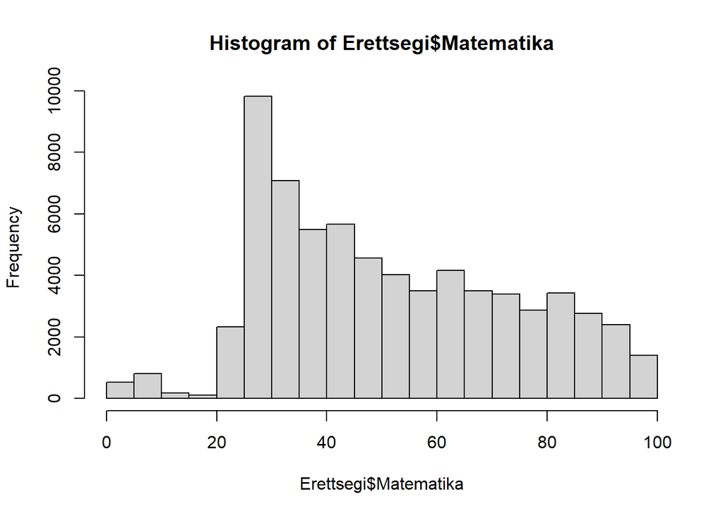

```r
hist(Erettsegi$Matematika)
```

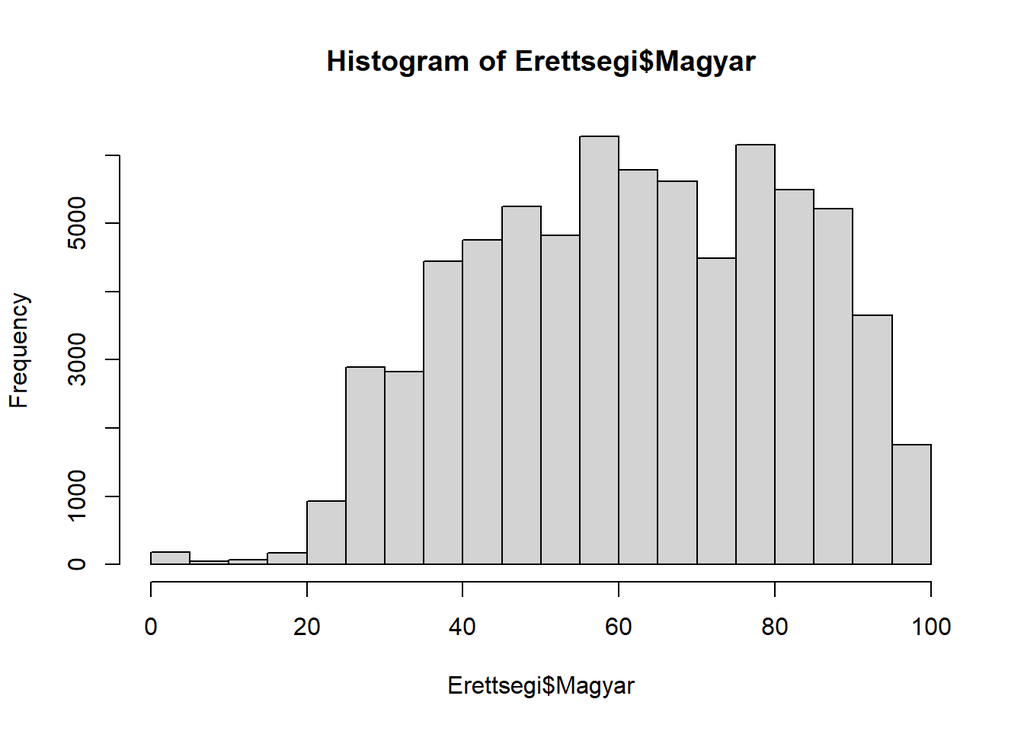

```r
hist(Erettsegi$Magyar)
```

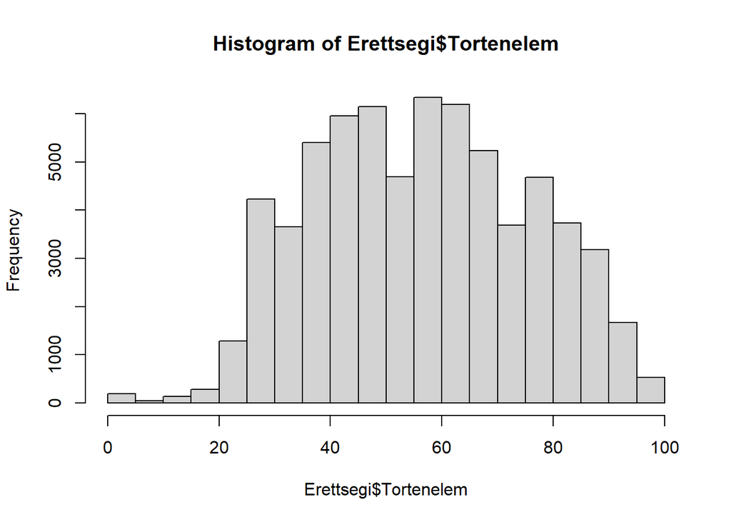

```r
hist(Erettsegi$Tortenelem)
```

A hiszogramok alapján a következő megállapításokat tehetjük tantárgyanként:

- **Matek**: Az alacsony pontszámokból van sok, és a nagy pontszámokból egyre kevesebb fordul elő. A hisztogramot elnézve az igazán nagy, 100 körüli pontszámok már kimondottan ritkaságszámba mennek. Tehát már-már azt mondhatjuk, hogy *fefelé kilógó értékei vannak ennek a változónak*. Az ilyen alakú hisztogrammal bíró változót hívjuk **jobbra elnyúló eloszlású változó**nak.
- **Magyar**: A magasabb pontszámokból van sok, és a kisebb pontokból egyre kevesebb fordul elő. A hisztogram alapján az igazán kicsi, olyan 20-30 alatti pontszámok egészen ritkának mondható. Már-már azt mondhatjuk, hogy *lefelé kilógó értékei vannak ennek a változónak*. Az ilyen alakú hisztogrammal bíró változót hívjuk **balra elnyúló eloszlású változó**nak.
- **Történelem**: A pontszámok nagyjából a változó értékkészletének közepén helyezkednek el, és a kimondottan kis és nagy pontszámok felé haladva kb. arányosan “fogy el” a gyakoriság. Kimondottan a gyakoriságok maximumától (tehát a módusztól) *kilógóan távoli adat egyik irányban sem nagyon van*. Az ilyen alakú hisztogrammal bíró változót hívjuk **szimmetrikus vagy normális eloszlású változó**nak.

A **normális eloszlású** változóknak központi szerepe van a statisztikában, mivel ilyenkor a **változó értékei véletlen hatások összegződésével állnak elő**. Azaz, az értékeknek nincs torzítása az értékkészlet egyik irányában sem: nem a kimondottan kicsi vagy nagy értékekből van sok, hanem az értékkészlet közepén fordul elő a legtöbb adatpont. Ezt a jelenséget mondja ki kicsit matematizáltabban a [centrális határeloszlás-tétel](https://hu.wikipedia.org/wiki/Centr%C3%A1lis_hat%C3%A1reloszl%C3%A1s-t%C3%A9tel), rövidítve *CHT*.

A változó eloszlásának alakja hatással van a három helyzetmutatónk (az átlag = $\bar{Y}$, módusz = $Mo$, medián = $Me$ szentháromság) egymáshoz képesti viszonyára is az alábbi ábrán látható módon:

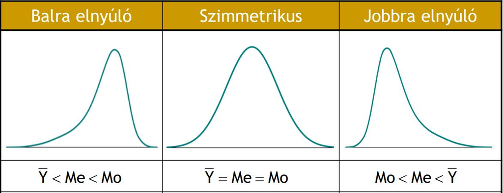

Mint láthatjuk, hogy a *három helyzetmutató viszonya attól függ hol vannak a kilógó értékek az eloszlásban*: a jobbra elnyúlónál felül, így a kilógó értékekre érzékeny átlag magasabb, mint a másik két helyzetmutató; balra elnyúlás esetén pedig az átlag a legkisebb érték a három közül, mert a kilógó értékek lefelé találhatók az eloszlásban.

Ellenőrizzük le ezt a tulajdonságot mindhárom változóban.

Vegyük először a **jobbra elnyúló eloszlású matek** eredményeket. A `median` és `mean` függvényben használnunk kell a `na.rm = TRUE` beállítást, mivel nem ugyan annyian érettségiztek magyarból, matekból és töriből, így lehetnek hiányzó értékek az egyes változókban, és ezeket nem kell figyelembe venni a medián és az átlag számolásnál:

```r
# Módusz
gyak_matek <- table(Erettsegi$Matematika)
gyak_matek[gyak_matek==max(gyak_matek)]
```

```
##   26
## 2452
```

```r
# Medián
median(Erettsegi$Matematika, na.rm = TRUE)
```

```
## [1] 48
```

```r
# Átlag
mean(Erettsegi$Matematika, na.rm = TRUE)
```

```
## [1] 51.76812
```

Tényleg $Mo < Me < \bar{Y}$, azaz $26<48<51.7$ a sorrend. :)

Lássuk a **balra elnyúló magyar** pontokat:

```r
# Módusz
gyak_magyar<- table(Erettsegi$Magyar)
gyak_magyar[gyak_magyar==max(gyak_magyar)]
```

```
##   80
## 4086
```

```r
# Medián
median(Erettsegi$Magyar, na.rm = TRUE)
```

```
## [1] 62
```

```r
# Átlag
mean(Erettsegi$Magyar, na.rm = TRUE)
```

```
## [1] 62.62998
```

Itt is nagyjából stimmel a sorrend ($Mo > Me > \bar{Y}$), bár a medián és az átlag inkább egyenlőnek vehető: $80>62 \approx 62.6$. Ez annyit jelent, hogy a lefelé kilógó értékek hatása nem olyan jelentős, hogy az átlagot nagyon megmozgassa a mediánhoz képest, de az szépen látszik, hogy a leggyakoribb eredmény, a 80 pont az lényegesen magasabb, mint az átlag (és medián) értéke.

Végül pedig akkor lessük meg mi a helyzet a **szimmetrikus töri** eredményekkel:

```r
# Módusz
gyak_tori<- table(Erettsegi$Tortenelem)
gyak_tori[gyak_tori==max(gyak_tori)]
```

```
##   60
## 4235
```

```r
# Medián
median(Erettsegi$Tortenelem, na.rm = TRUE)
```

```
## [1] 58
```

```r
# Átlag
mean(Erettsegi$Tortenelem, na.rm = TRUE)
```

```
## [1] 57.00512
```

Ez alapján elmondható, hogy mindhárom helyzetmutató kb. $58$ körüli, szóval megközelítőleg azonosnak tekinthetők.

Az eloszlások alakjának eltérését meg szokták mérni a kitüntetett helyzetben lévő **normális eloszlás**tól. Egyrészt megmérik az eloszlás ferdeségét (aszimmetriáját) a normális eloszláshoz képest, tehát azt, hogy mennyire jobbra/balra elnyúló. Ennek az eszköze az $\alpha_3$ mutató, amit a következőképpen lehet értelmezni:

- $-0.1 ≤ \alpha_3 ≤ + 0.1$ –> az eloszlás szimmetrikus
- $\alpha_3 > + 0.1$ –> az eloszlás jobbra elnyúló
- $-0,1 > \alpha_3$ –> az eloszlás balra elnyúló

Tehát kb. azt mondhatjuk nagy vonalakban, hogy ha a mutató kb. 0, akkor szimmetrikus az eloszlás, ha pozitív akkor jobbra elnyúló, ha negatív, akkor balra elnyúló.

Ehhez képest lehet mérni az eloszlás csúcsosságát/lapultságát is a normális eloszláshoz képest, mivel még ha az eloszlás szimmetrikus is, akkor is lehet hogy a módusz, mint legnagyobb gyakoriságú elem (tehát a hisztogram maximuma) köré jobban/kevésbé csoportosulnak a konkrét értékek:

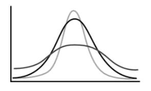

A csúcsosság jelenségét az $\alpha_4$ csúcsossági mutatóval mérjük, aminek az értelmezését a következó módon lehet megtenni az $\alpha_3$-hoz hasonló módon:

- $-0.1 ≤ \alpha_4 ≤ + 0.1$ –> az eloszlás normális csúcsosságú
- $\alpha_4 > + 0.1$ –> az eloszlás a normális eloszlásnál csúcsosabb
- $-0,1 > \alpha_4$ –> az eloszlás baa normális eloszlásnál lapultabb

Tehát kb. azt mondhatjuk nagy vonalakban, hogy ha a mutató kb. 0, akkor normális csúcsosságú az eloszlás, ha pozitív akkor a normálisnál csúcsosabb, ha negatív, akkor a normálisnál lapultabb.

Az $\alpha_3$ és $\alpha_4$ mutatókat R-ben, sok más alap leíró statisztikai mutatóval együtt a `psych` csomag `describe` függvényével lehet kiszámolni.

Telepítsük és hivatkozzuk be az R-be a csomagot:

```r
install.packages("psych")
library(psych) # Szokásos módon ne törődjünk az esetleges Warningokkal! :)
```

Majd alkalmazzuk a `describe` függvényt az **Erettsegi** `data frame`-n:

```r
describe(Erettsegi)
```

```
##            vars     n  mean    sd median trimmed   mad min max range  skew
## Matematika    1 67989 51.77 22.28     48   50.61 25.20   0 100   100  0.33
## Magyar        2 70812 62.63 19.95     62   63.10 26.69   0 100   100 -0.18
## Tortenelem    3 67240 57.01 19.17     58   56.89 22.24   0 100   100  0.03
##            kurtosis   se
## Matematika    -0.85 0.09
## Magyar        -0.82 0.07
## Tortenelem    -0.77 0.07
```

Mint láthatjuk, a függvény nagyon sok hasznos statisztikai mutatót ad vissza az eddig tanultak közül a `data frame` mindhárom változójára:

A mostani fejezetünk szempontjából az az érdekes, hogy a **kurtosis**, azaz $\alpha_4$ mutató értéke mindhárom változóra kisebb, mint $-0.1$, így mindhárom változó eloszlása lapultnak tekinthető, tehát a módusz körül a normálisnál jobban szóródnak az értékek. De a legkevésbé lapult eloszlása a töri pontszámoknak van.  
Ezen kívül látjuk, hogy a magyar pontok eloszlása balra elnyúló, mivel $\alpha_3$ itt kisebb, mint $-0.1$. A matek pontszámok a jobbra elnyúlásnak megfelelően $\alpha_3=0.33>0.1$-et mutatnak, míg a szimmetrikus töri pontok $0.03$-as $\alpha_3$ értéke a várakozásoknak megfelelően $\pm 0.1$ közötti érték.

De ilyen dolgokat is meg lehet állapítani a `describe` eredményéből, hogy a legbizonytalanabb eredményeket a matematika pontszámok adják, mert az ő $\frac{22.28}{51.77}=0.43$-as relatív szórásuk a legnagyobb. Tehát, bár a matek pontszámok átlag és medián szinten is a legkisebbek, de itt van a legnagyobb szóródás is, az átlag $43\%$-os környezetében helyezkednek el a konkrét tanulók matek pontszámai. Ehhez képest a másik két tárgy pontjainak relatív szórása csak $\frac{19.95}{62.63}=0.318=31.8\%$ és $\frac{19.17}{57.01}=0.336=33.6\%$.

### 6.1. A `describe` függvény és a `factor` adattípus

Nézzük meg hogyan reagál a `describe` függvény arra, ha ráeresztjük a teljes **titanic** `data frame`-re, amiben vannak minőségi változók (név, nem, túlélt-e, stb.) is:

```r
describe(titanic)
```

```
##                  vars    n   mean     sd median trimmed    mad  min     max
## Osztaly*            1 1043   2.21   0.84   2.00    2.26   1.48 1.00    3.00
## Tulelt_e*           2 1043   1.59   0.49   2.00    1.62   0.00 1.00    2.00
## Nev*                3 1043 520.78 300.49 521.00  520.73 385.48 1.00 1041.00
## Nem*                4 1043   1.37   0.48   1.00    1.34   0.00 1.00    2.00
## Kor                 5 1043  29.81  14.37  28.00   29.33  11.86 0.17   80.00
## Viteldij            6 1043  36.60  55.75  15.75   23.81  12.16 0.00  512.33
## BeszallasHelye*     7 1043   2.55   0.81   3.00    2.68   0.00 1.00    3.00
## CsaladtagokSzama    8 1043   0.93   1.45   0.00    0.60   0.00 0.00   10.00
##                    range  skew kurtosis   se
## Osztaly*            2.00 -0.41    -1.47 0.03
## Tulelt_e*           1.00 -0.38    -1.86 0.02
## Nev*             1040.00  0.00    -1.20 9.30
## Nem*                1.00  0.54    -1.71 0.01
## Kor                79.83  0.41     0.15 0.44
## Viteldij          512.33  4.11    23.52 1.73
## BeszallasHelye*     2.00 -1.30    -0.21 0.03
## CsaladtagokSzama   10.00  2.14     5.15 0.05
```

Azt vegyük észre az eredményen, hogy a nem `double` típusú változóinkra (egy `character` és a négy `factor`) nem mutat ki semmi értelmes dolgot a változók eloszlásairól. Emiatt is kaptunk az érintett minőségi változók nevéhez egy *csillagot*!!  
Ilyen szempontból a `summary` függvény intelligensebb jószág. Ez a `describe` alapvetően a **numerikus változók** alaposabb leíró statisztikai elemzésére alkalmas.

## 7. A doboz ábra

Miután annyit beszélgettünk arról, hogyan hatnak a különböző irányú kilógó értékek egy változóban a különböző statisztikai mutatóinkra, főleg az átlagra, jó lenne egy **eszköz**t nézni, **amivel ezek a kilógó értékek azonosíthatók egy változóban**.  
Nos, ez az eszköz lesz a **doboz ábra**.

A doboz ábrán gyakorlatilag a `summary` függvény eredménye jelenik meg, mivel az ábrán látható a változó **mediánja** valamint **alsó és felső kvartilise**. Egy általános doboz ábra az alábbi alakot ölti R-ben:

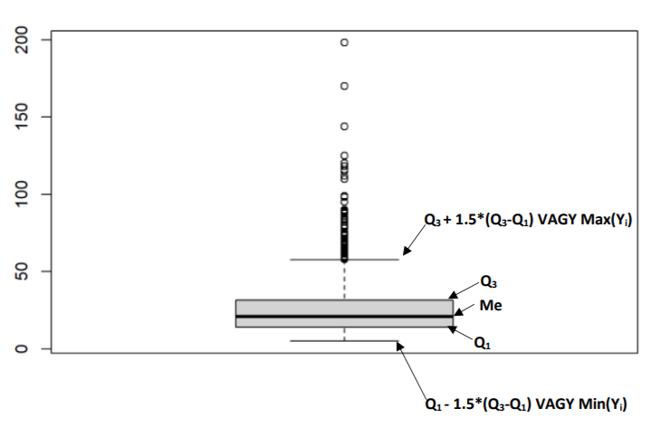

A doboz ábrán tehát a “**doboz**” nem más, mint az alsó és felső kvartilis által közrezárt tartomány, azaz a **változó értékeinek középső 50%-a**. Más szóval az **interkvartilis terjedelem**, alias $IKT=Q_3-Q_1$.

A 3 db kvartilisen kívül a doboz ábra a **Tukey-féle kerítések** segítségével jelzi az adatsor kilógó értékeit. A Tukey-féle kerítések alapján egy *változó azon értékei minősülnek kilógónak, amelyek a változó középső 50%-hoz*, tehát az IKT-hez *képest túl messze helyezkednek el* (akár felfelé, akár lefelé). Konkrétan a két irányba így számolhatók ezek a kerítések: $Felso=Q_3+1.5 \times (Q_3-Q_1)$ és $Also=Q_1-1.5 \times (Q_3-Q_1)$. Ha a változónk egy $Y_i$ értéke kisebb, mint az $Also$ kerítés, akkor lefelé számít kilógó értéknek, míg ha az $Y_i$ érték nagyobb, mint a $Felso$ kerítés, akkor felfelé számít kilógó értéknek.  
A doboz ábra pedig úgy működik, hogy ha **van valamelyik kerítésen túllógó érték**, akkor azokat már, **mint kilógó értékeket, külön-külön pontként jeleníti meg**, míg ha **valamelyik kerítésen nincs túllógó érték**, akkor a doboz ábra a **változó minimumát vagy maximumát mutatja az ábrán** az iránynak (felső/alsó kerítés) megfelelően.

Mindezen megfontolások alapján könnyen látható már talán, hogy a **fenti minta doboz ábra egy jobbra elnyúló eloszláshoz** tartozik: Az adatok középső 50%-a (a doboz) az adatok minimumához közelebb van, mint a maximumához, és felfelé találhatók pontok, azaz kilógó értékek.  
Egy **balra elnyúló eloszlás doboz ábrája pont a fordítottja lenne a fentinek**: Az adatok középső 50%-a (a doboz) az adatok maximumához közelebb lenne, mint a minimumához, és lefelé lennének találhatók pontok, azaz kilógó értékek:

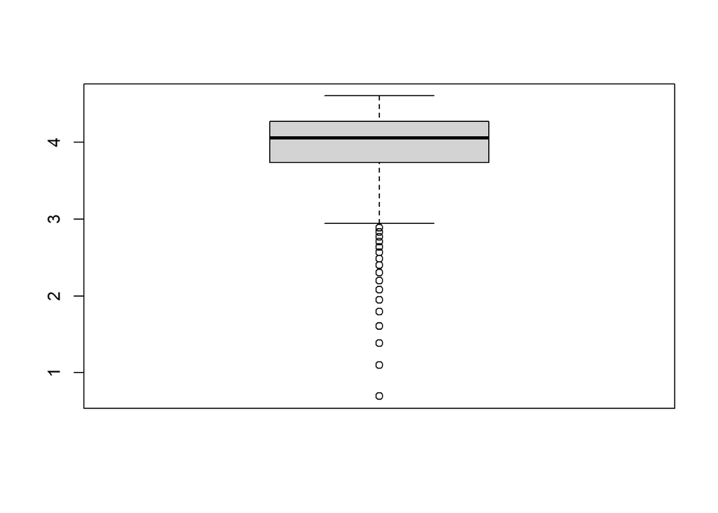

**Szimmetrikus esetben** pedig a doboz ábrán a **doboz középen helyezkedne el**, se aminimumhoz, se a maximumhoz nem lenne kimondottan közel, és **vagy mindkét irányban vagy egyik irányban sem lennének pontok, azaz kilógó értékek**. Egy példa ábra szimmetrikus esetben az alábbi:

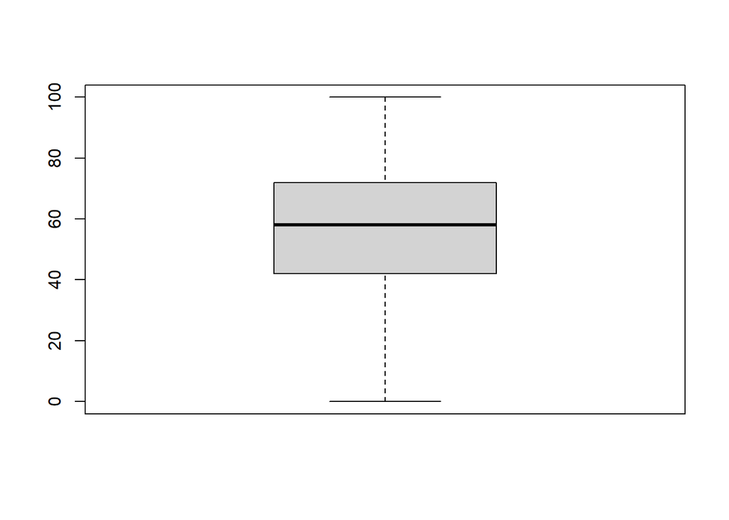

Egy doboz ábrát az R-ben a `boxplot` függvénnyel tudunk generálni. Próbáljuk is ki a **titanic** `data frame` **Viteldij** változóján, és nézzük meg a változóra ráeresztett `summary` függvény eredményét is :

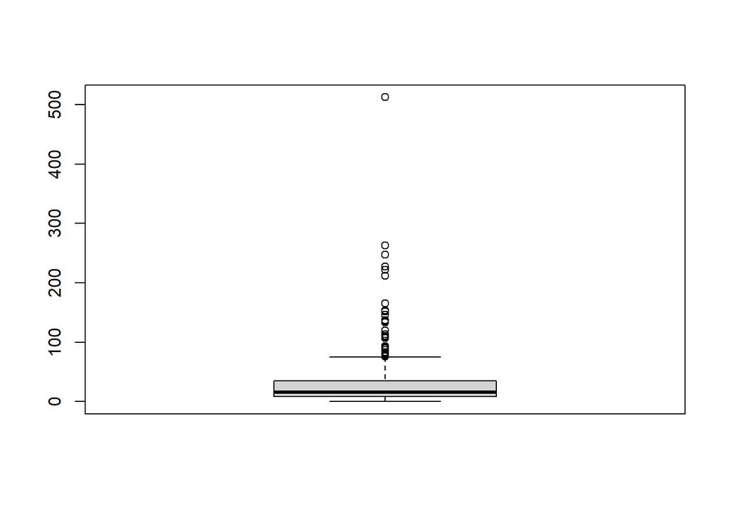

```r
boxplot(titanic$Viteldij)
```

```r
summary(titanic$Viteldij)
```

```
##    Min. 1st Qu.  Median    Mean 3rd Qu.    Max.
##    0.00    8.05   15.75   36.60   35.08  512.33
```

Egyébként, ez a **Tukey-féle kerítéses kilógó érték keresési eljárás elég aggresszív**. Ha a doboz ábrát alaposan megnézzük, akkor inkább csak azt a pár 200 font feletti viteldíjat kéne kilógóan magas díjaknak venni, de ezek sincsenek annyira vészesen elszakadva a “keménymagtól”, azaz a középső 50%-tól. Az *igazi-igazi kilógó értékek az 500 font feletti viteldíjak*. Szóval a **kilógó értékek határánál nem kell minden áron ragaszkodni a doboz ábra kerítéses módszeréhez**, a doboz ábra tényleges alakja és a józan ész kombinációjával felülírhatók a kerítésekből származó kilógó érték határok. :)